# Predict Bike Sharing Demand with AutoGluon

## Project: Predict Bike Sharing Demand with AutoGluon

This notebook is a template with each step that you need to complete for the project.

Please fill in your code where there are explicit `?` markers in the notebook. You are welcome to add more cells and code as you see fit.

Once you have completed all the code implementations, please export your notebook as a HTML file so the reviews can view your code. Make sure you have all outputs correctly outputted.

`File-> Export Notebook As... -> Export Notebook as HTML`

There is a writeup to complete as well after all code implememtation is done. Please answer all questions and attach the necessary tables and charts. You can complete the writeup in either markdown or PDF.

Completing the code template and writeup template will cover all of the rubric points for this project.

The rubric contains "Stand Out Suggestions" for enhancing the project beyond the minimum requirements. The stand out suggestions are optional. If you decide to pursue the "stand out suggestions", you can include the code in this notebook and also discuss the results in the writeup file.

## Step 2: Download the Kaggle dataset using the kaggle python library

### Open up Sagemaker Studio and use starter template

1. Notebook should be using a `ml.t3.medium` instance (2 vCPU + 4 GiB)
2. Notebook should be using kernal: `Python 3 (MXNet 1.8 Python 3.7 CPU Optimized)`

### Install packages

```python
!pip install -U pip
!pip install -U setuptools wheel
!pip install -U "mxnet<2.0.0" bokeh==2.0.1
!pip install autogluon --no-cache-dir
# Without --no-cache-dir, smaller aws instances may have trouble installing
```

[output not shown]

### Setup Kaggle API Key

```python
# create the .kaggle directory and an empty kaggle.json file
!mkdir -p /root/.kaggle
!touch /root/.kaggle/kaggle.json
!chmod 600 /root/.kaggle/kaggle.json
```

```python
# Fill in your user name and key from creating the kaggle account and API token file
import json
kaggle_username = "lucyledezma"
kaggle_key = "3bc0e5932298eb1acd5619a68d883ca7"

# Save API token the kaggle.json file
with open("/root/.kaggle/kaggle.json", "w") as f:
    f.write(json.dumps({"username": kaggle_username, "key": kaggle_key}))
```

### Download and explore dataset

### Go to the [bike sharing demand competition](https://www.kaggle.com/c/bike-sharing-demand) and agree to the terms

```python
# Download the dataset, it will be in a .zip file so you'll need to unzip it as well.
!pip install -U kaggle
!kaggle competitions download -c bike-sharing-demand
# If you already downloaded it you can use the -o command to overwrite the file
!unzip -o bike-sharing-demand.zip
```

```
WARNING: Running pip as the 'root' user can result in broken permissions and conflicting behaviour with the system package manager. It is recommended to use a virtual environment instead: https://pip.pypa.io/warnings/venv
Downloading bike-sharing-demand.zip to /root/AWS_project_bike_sharing_Ledezma_Lucia_del-Valle/project
Archive:  bike-sharing-demand.zip
  inflating: sampleSubmission.csv
  inflating: test.csv
  inflating: train.csv
```

```python
import pandas as pd
from autogluon.tabular import TabularPredictor
```

```python
# Create the train dataset in pandas by reading the csv
# Set the parsing of the datetime column so you can use some of the `dt` features in pandas later
train = pd.read_csv("train.csv")
train["datetime"] = pd.to_datetime(train["datetime"])
train.head()
```

|  | datetime | season | holiday | workingday | weather | temp | atemp | humidity | windspeed | casual | registered | count |
| --- | --- | --- | --- | --- | --- | --- | --- | --- | --- | --- | --- | --- |
| 0 | 2011-01-01 00:00:00 | 1 | 0 | 0 | 1 | 9.84 | 14.395 | 81 | 0.0 | 3 | 13 | 16 |
| 1 | 2011-01-01 01:00:00 | 1 | 0 | 0 | 1 | 9.02 | 13.635 | 80 | 0.0 | 8 | 32 | 40 |
| 2 | 2011-01-01 02:00:00 | 1 | 0 | 0 | 1 | 9.02 | 13.635 | 80 | 0.0 | 5 | 27 | 32 |
| 3 | 2011-01-01 03:00:00 | 1 | 0 | 0 | 1 | 9.84 | 14.395 | 75 | 0.0 | 3 | 10 | 13 |
| 4 | 2011-01-01 04:00:00 | 1 | 0 | 0 | 1 | 9.84 | 14.395 | 75 | 0.0 | 0 | 1 | 1 |

```python
# Simple output of the train dataset to view some of the min/max/varition of the dataset features.
train.describe()
```

|  | season | holiday | workingday | weather | temp | atemp | humidity | windspeed | casual | registered | count |
| --- | --- | --- | --- | --- | --- | --- | --- | --- | --- | --- | --- |
| count | 10886.000000 | 10886.000000 | 10886.000000 | 10886.000000 | 10886.00000 | 10886.000000 | 10886.000000 | 10886.000000 | 10886.000000 | 10886.000000 | 10886.000000 |
| mean | 2.506614 | 0.028569 | 0.680875 | 1.418427 | 20.23086 | 23.655084 | 61.886460 | 12.799395 | 36.021955 | 155.552177 | 191.574132 |
| std | 1.116174 | 0.166599 | 0.466159 | 0.633839 | 7.79159 | 8.474601 | 19.245033 | 8.164537 | 49.960477 | 151.039033 | 181.144454 |
| min | 1.000000 | 0.000000 | 0.000000 | 1.000000 | 0.82000 | 0.760000 | 0.000000 | 0.000000 | 0.000000 | 0.000000 | 1.000000 |
| 25% | 2.000000 | 0.000000 | 0.000000 | 1.000000 | 13.94000 | 16.665000 | 47.000000 | 7.001500 | 4.000000 | 36.000000 | 42.000000 |
| 50% | 3.000000 | 0.000000 | 1.000000 | 1.000000 | 20.50000 | 24.240000 | 62.000000 | 12.998000 | 17.000000 | 118.000000 | 145.000000 |
| 75% | 4.000000 | 0.000000 | 1.000000 | 2.000000 | 26.24000 | 31.060000 | 77.000000 | 16.997900 | 49.000000 | 222.000000 | 284.000000 |
| max | 4.000000 | 1.000000 | 1.000000 | 4.000000 | 41.00000 | 45.455000 | 100.000000 | 56.996900 | 367.000000 | 886.000000 | 977.000000 |

```python
# Create the test pandas dataframe in pandas by reading the csv, remember to parse the datetime!
test = pd.read_csv("test.csv")
test["datetime"] = pd.to_datetime(test["datetime"])
test.head()
```

|  | datetime | season | holiday | workingday | weather | temp | atemp | humidity | windspeed |
| --- | --- | --- | --- | --- | --- | --- | --- | --- | --- |
| 0 | 2011-01-20 00:00:00 | 1 | 0 | 1 | 1 | 10.66 | 11.365 | 56 | 26.0027 |
| 1 | 2011-01-20 01:00:00 | 1 | 0 | 1 | 1 | 10.66 | 13.635 | 56 | 0.0000 |
| 2 | 2011-01-20 02:00:00 | 1 | 0 | 1 | 1 | 10.66 | 13.635 | 56 | 0.0000 |
| 3 | 2011-01-20 03:00:00 | 1 | 0 | 1 | 1 | 10.66 | 12.880 | 56 | 11.0014 |
| 4 | 2011-01-20 04:00:00 | 1 | 0 | 1 | 1 | 10.66 | 12.880 | 56 | 11.0014 |

```python
# Same thing as train and test dataset
submission = pd.read_csv("sampleSubmission.csv")
submission.head()
```

|  | datetime | count |
| --- | --- | --- |
| 0 | 2011-01-20 00:00:00 | 0 |
| 1 | 2011-01-20 01:00:00 | 0 |
| 2 | 2011-01-20 02:00:00 | 0 |
| 3 | 2011-01-20 03:00:00 | 0 |
| 4 | 2011-01-20 04:00:00 | 0 |

## Step 3: Train a model using AutoGluon’s Tabular Prediction

Requirements:

- We are predicting `count`, so it is the label we are setting.
- Ignore `casual` and `registered` columns as they are also not present in the test dataset.
- Use the `root_mean_squared_error` as the metric to use for evaluation.
- Set a time limit of 10 minutes (600 seconds).
- Use the preset `best_quality` to focus on creating the best model.

```python
predictor = TabularPredictor(label="count", eval_metric="root_mean_squared_error", learner_kwargs={"ignored_columns": ["casual", "registered"]}).fit(train_data=train, time_limit=600, presets="best_quality")
```

```
No path specified. Models will be saved in: "AutogluonModels/ag-20221229_000649/"
Presets specified: ['best_quality']
Stack configuration (auto_stack=True): num_stack_levels=1, num_bag_folds=8, num_bag_sets=20
Beginning AutoGluon training ... Time limit = 600s
AutoGluon will save models to "AutogluonModels/ag-20221229_000649/"
AutoGluon Version:  0.6.1
Python Version:     3.7.10
Operating System:   Linux
Platform Machine:   x86_64
Platform Version:   #1 SMP Wed Oct 26 20:36:53 UTC 2022
Train Data Rows:    10886
Train Data Columns: 11
Label Column: count
Preprocessing data ...
AutoGluon infers your prediction problem is: 'regression' (because dtype of label-column == int and many unique label-values observed).
	Label info (max, min, mean, stddev): (977, 1, 191.57413, 181.14445)
	If 'regression' is not the correct problem_type, please manually specify the problem_type parameter during predictor init (You may specify problem_type as one of: ['binary', 'multiclass', 'regression'])
Using Feature Generators to preprocess the data ...
Dropping user-specified ignored columns: ['casual', 'registered']
Fitting AutoMLPipelineFeatureGenerator...
	Available Memory:                    1960.88 MB
	Train Data (Original)  Memory Usage: 0.78 MB (0.0% of available memory)
	Inferring data type of each feature based on column values. Set feature_metadata_in to manually specify special dtypes of the features.
	Stage 1 Generators:
		Fitting AsTypeFeatureGenerator...
			Note: Converting 2 features to boolean dtype as they only contain 2 unique values.
	Stage 2 Generators:
		Fitting FillNaFeatureGenerator...
	Stage 3 Generators:
		Fitting IdentityFeatureGenerator...
		Fitting DatetimeFeatureGenerator...
	Stage 4 Generators:
		Fitting DropUniqueFeatureGenerator...
	Types of features in original data (raw dtype, special dtypes):
		('datetime', []) : 1 | ['datetime']
		('float', [])    : 3 | ['temp', 'atemp', 'windspeed']
		('int', [])      : 5 | ['season', 'holiday', 'workingday', 'weather', 'humidity']
	Types of features in processed data (raw dtype, special dtypes):
		('float', [])                : 3 | ['temp', 'atemp', 'windspeed']
		('int', [])                  : 3 | ['season', 'weather', 'humidity']
```

[output cut: 64 more lines]

```
	-53.4512	 = Validation score   (-root_mean_squared_error)
	26.19s	 = Training   runtime
	0.59s	 = Validation runtime
Fitting model: CatBoost_BAG_L2 ... Training model for up to 58.84s of the 58.81s of remaining time.
	Fitting 8 child models (S1F1 - S1F8) | Fitting with ParallelLocalFoldFittingStrategy
	-55.6469	 = Validation score   (-root_mean_squared_error)
	58.35s	 = Training   runtime
	0.05s	 = Validation runtime
Completed 1/20 k-fold bagging repeats ...
Fitting model: WeightedEnsemble_L3 ... Training model for up to 360.0s of the -3.46s of remaining time.
	-53.1175	 = Validation score   (-root_mean_squared_error)
	0.42s	 = Training   runtime
	0.0s	 = Validation runtime
AutoGluon training complete, total runtime = 604.1s ... Best model: "WeightedEnsemble_L3"
TabularPredictor saved. To load, use: predictor = TabularPredictor.load("AutogluonModels/ag-20221229_000649/")
```

### Review AutoGluon's training run with ranking of models that did the best.

```python
predictor.fit_summary()
```

```
*** Summary of fit() ***
Estimated performance of each model:
                     model   score_val  pred_time_val    fit_time  pred_time_val_marginal  fit_time_marginal  stack_level  can_infer  fit_order
0      WeightedEnsemble_L3  -53.117461      14.155366  551.307876                0.000868           0.420542            3       True         14
1   RandomForestMSE_BAG_L2  -53.451156      10.487193  411.109396                0.590962          26.193374            2       True         12
2          LightGBM_BAG_L2  -55.097050      10.110964  410.771354                0.214733          25.855333            2       True         11
3          CatBoost_BAG_L2  -55.646882       9.942439  443.270452                0.046208          58.354430            2       True         13
4        LightGBMXT_BAG_L2  -60.364450      13.302595  440.484197                3.406364          55.568176            2       True         10
5    KNeighborsDist_BAG_L1  -84.125061       0.105389    0.030121                0.105389           0.030121            1       True          2
6      WeightedEnsemble_L2  -84.125061       0.106452    0.717815                0.001063           0.687695            2       True          9
7    KNeighborsUnif_BAG_L1 -101.546199       0.104798    0.032217                0.104798           0.032217            1       True          1
8   RandomForestMSE_BAG_L1 -116.544294       0.572505   11.135215                0.572505          11.135215            1       True          5
9     ExtraTreesMSE_BAG_L1 -124.588053       0.522585    5.047746                0.522585           5.047746            1       True          7
10         CatBoost_BAG_L1 -130.533194       0.127669  201.555580                0.127669         201.555580            1       True          6
11         LightGBM_BAG_L1 -131.054162       1.517289   30.241318                1.517289          30.241318            1       True          4
12       LightGBMXT_BAG_L1 -131.460909       6.502751   68.470494                6.502751          68.470494            1       True          3
13  NeuralNetFastAI_BAG_L1 -138.717867       0.443246   68.403332                0.443246          68.403332            1       True          8
Number of models trained: 14
Types of models trained:
{'StackerEnsembleModel_NNFastAiTabular', 'StackerEnsembleModel_CatBoost', 'StackerEnsembleModel_XT', 'StackerEnsembleModel_KNN', 'StackerEnsembleModel_LGB', 'StackerEnsembleModel_RF', 'WeightedEnsembleModel'}
Bagging used: True  (with 8 folds)
Multi-layer stack-ensembling used: True  (with 3 levels)
Feature Metadata (Processed):
(raw dtype, special dtypes):
('float', [])                : 3 | ['temp', 'atemp', 'windspeed']
('int', [])                  : 3 | ['season', 'weather', 'humidity']
('int', ['bool'])            : 2 | ['holiday', 'workingday']
('int', ['datetime_as_int']) : 5 | ['datetime', 'datetime.year', 'datetime.month', 'datetime.day', 'datetime.dayofweek']
Plot summary of models saved to file: AutogluonModels/ag-20221229_000649/SummaryOfModels.html
*** End of fit() summary ***
```

```
{'model_types': {'KNeighborsUnif_BAG_L1': 'StackerEnsembleModel_KNN',
  'KNeighborsDist_BAG_L1': 'StackerEnsembleModel_KNN',
  'LightGBMXT_BAG_L1': 'StackerEnsembleModel_LGB',
  'LightGBM_BAG_L1': 'StackerEnsembleModel_LGB',
  'RandomForestMSE_BAG_L1': 'StackerEnsembleModel_RF',
  'CatBoost_BAG_L1': 'StackerEnsembleModel_CatBoost',
  'ExtraTreesMSE_BAG_L1': 'StackerEnsembleModel_XT',
  'NeuralNetFastAI_BAG_L1': 'StackerEnsembleModel_NNFastAiTabular',
  'WeightedEnsemble_L2': 'WeightedEnsembleModel',
  'LightGBMXT_BAG_L2': 'StackerEnsembleModel_LGB',
  'LightGBM_BAG_L2': 'StackerEnsembleModel_LGB',
  'RandomForestMSE_BAG_L2': 'StackerEnsembleModel_RF',
  'CatBoost_BAG_L2': 'StackerEnsembleModel_CatBoost',
  'WeightedEnsemble_L3': 'WeightedEnsembleModel'},
 'model_performance': {'KNeighborsUnif_BAG_L1': -101.54619908446061,
  'KNeighborsDist_BAG_L1': -84.12506123181602,
  'LightGBMXT_BAG_L1': -131.46090891834504,
  'LightGBM_BAG_L1': -131.054161598899,
  'RandomForestMSE_BAG_L1': -116.54429428704391,
  'CatBoost_BAG_L1': -130.5331939673838,
  'ExtraTreesMSE_BAG_L1': -124.58805258915959,
  'NeuralNetFastAI_BAG_L1': -138.7178667847098,
  'WeightedEnsemble_L2': -84.12506123181602,
  'LightGBMXT_BAG_L2': -60.36445039992359,
  'LightGBM_BAG_L2': -55.097049969576005,
  'RandomForestMSE_BAG_L2': -53.4511562252362,
  'CatBoost_BAG_L2': -55.646881729501324,
  'WeightedEnsemble_L3': -53.1174612970912},
 'model_best': 'WeightedEnsemble_L3',
 'model_paths': {'KNeighborsUnif_BAG_L1': 'AutogluonModels/ag-20221229_000649/models/KNeighborsUnif_BAG_L1/',
  'KNeighborsDist_BAG_L1': 'AutogluonModels/ag-20221229_000649/models/KNeighborsDist_BAG_L1/',
  'LightGBMXT_BAG_L1': 'AutogluonModels/ag-20221229_000649/models/LightGBMXT_BAG_L1/',
  'LightGBM_BAG_L1': 'AutogluonModels/ag-20221229_000649/models/LightGBM_BAG_L1/',
  'RandomForestMSE_BAG_L1': 'AutogluonModels/ag-20221229_000649/models/RandomForestMSE_BAG_L1/',
  'CatBoost_BAG_L1': 'AutogluonModels/ag-20221229_000649/models/CatBoost_BAG_L1/',
  'ExtraTreesMSE_BAG_L1': 'AutogluonModels/ag-20221229_000649/models/ExtraTreesMSE_BAG_L1/',
  'NeuralNetFastAI_BAG_L1': 'AutogluonModels/ag-20221229_000649/models/NeuralNetFastAI_BAG_L1/',
  'WeightedEnsemble_L2': 'AutogluonModels/ag-20221229_000649/models/WeightedEnsemble_L2/',
  'LightGBMXT_BAG_L2': 'AutogluonModels/ag-20221229_000649/models/LightGBMXT_BAG_L2/',
  'LightGBM_BAG_L2': 'AutogluonModels/ag-20221229_000649/models/LightGBM_BAG_L2/',
```

[output cut: 126 more lines]

```
     fit_order
 0          14
 1          12
 2          11
 3          13
 4          10
 5           2
 6           9
 7           1
 8           5
 9           7
 10          6
 11          4
 12          3
 13          8  }
```

### Create predictions from test dataset

```python
predictions = predictor.predict(test)
predictions.head()
```

```
0    23.576309
1    42.229565
2    46.156635
3    49.802223
4    52.352642
Name: count, dtype: float32
```

#### NOTE: Kaggle will reject the submission if we don't set everything to be > 0.

```python
# Describe the `predictions` series to see if there are any negative values
predictions.describe()
```

```
count    6493.000000
mean      100.872604
std        89.904556
min         3.063907
25%        19.718273
50%        64.229752
75%       167.704025
max       365.119995
Name: count, dtype: float64
```

```python
# How many negative values do we have?
predictions[predictions < 0].count()
```

```
0
```

```python
# Set them to zero
predictions[predictions < 0] = 0
```

### Set predictions to submission dataframe, save, and submit

```python
submission["count"] = predictions
submission.to_csv("submission.csv", index=False)
```

```python
!kaggle competitions submit -c bike-sharing-demand -f submission.csv -m "first raw submission"
```

```
Successfully submitted to Bike Sharing Demand
```

#### View submission via the command line or in the web browser under the competition's page - `My Submissions`

```python
!kaggle competitions submissions -c bike-sharing-demand | tail -n +1 | head -n 3
```

```
fileName                       date                 description                          status    publicScore  privateScore
-----------------------------  -------------------  -----------------------------------  --------  -----------  ------------
submission.csv                 2022-12-29 00:17:33  first raw submission                 complete  1.79209      1.79209
tail: write error: Broken pipe
```

## Step 4: Exploratory Data Analysis and Creating an additional feature

- Any additional feature will do, but a great suggestion would be to separate out the datetime into hour, day, or month parts.

```
array([[<AxesSubplot:title={'center':'datetime'}>,
        <AxesSubplot:title={'center':'season'}>,
        <AxesSubplot:title={'center':'holiday'}>],
       [<AxesSubplot:title={'center':'workingday'}>,
        <AxesSubplot:title={'center':'weather'}>,
        <AxesSubplot:title={'center':'temp'}>],
       [<AxesSubplot:title={'center':'atemp'}>,
        <AxesSubplot:title={'center':'humidity'}>,
        <AxesSubplot:title={'center':'windspeed'}>],
       [<AxesSubplot:title={'center':'casual'}>,
        <AxesSubplot:title={'center':'registered'}>,
        <AxesSubplot:title={'center':'count'}>]], dtype=object)
```

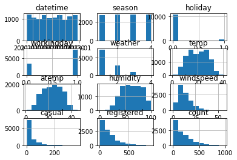

```python
# Create a histogram of all features to show the distribution of each one relative to the data. This is part of the exploritory data analysis
train.hist()
```

```python
# create a new feature
train["hour"] = train["datetime"].dt.hour
test["hour"] = test["datetime"].dt.hour
# Model Deployment Workflow. 8. Data Cleasing and Feature Engeneering : datetime parser
```

## Make category types for these so models know they are not just numbers

- AutoGluon originally sees these as ints, but in reality they are int representations of a category.
- Setting the dtype to category will classify these as categories in AutoGluon.

```python
train["season"] = train["season"].astype("category")
train["weather"] = train["weather"].astype("category")
test["season"] = test["season"].astype("category")
test["weather"] = test["weather"].astype("category")
```

```python
# View are new feature
train.head()
```

|  | datetime | season | holiday | workingday | weather | temp | atemp | humidity | windspeed | casual | registered | count | hour |
| --- | --- | --- | --- | --- | --- | --- | --- | --- | --- | --- | --- | --- | --- |
| 0 | 2011-01-01 00:00:00 | 1 | 0 | 0 | 1 | 9.84 | 14.395 | 81 | 0.0 | 3 | 13 | 16 | 0 |
| 1 | 2011-01-01 01:00:00 | 1 | 0 | 0 | 1 | 9.02 | 13.635 | 80 | 0.0 | 8 | 32 | 40 | 1 |
| 2 | 2011-01-01 02:00:00 | 1 | 0 | 0 | 1 | 9.02 | 13.635 | 80 | 0.0 | 5 | 27 | 32 | 2 |
| 3 | 2011-01-01 03:00:00 | 1 | 0 | 0 | 1 | 9.84 | 14.395 | 75 | 0.0 | 3 | 10 | 13 | 3 |
| 4 | 2011-01-01 04:00:00 | 1 | 0 | 0 | 1 | 9.84 | 14.395 | 75 | 0.0 | 0 | 1 | 1 | 4 |

```
array([[<AxesSubplot:title={'center':'datetime'}>,
        <AxesSubplot:title={'center':'holiday'}>,
        <AxesSubplot:title={'center':'workingday'}>],
       [<AxesSubplot:title={'center':'temp'}>,
        <AxesSubplot:title={'center':'atemp'}>,
        <AxesSubplot:title={'center':'humidity'}>],
       [<AxesSubplot:title={'center':'windspeed'}>,
        <AxesSubplot:title={'center':'casual'}>,
        <AxesSubplot:title={'center':'registered'}>],
       [<AxesSubplot:title={'center':'count'}>,
        <AxesSubplot:title={'center':'hour'}>, <AxesSubplot:>]],
      dtype=object)
```

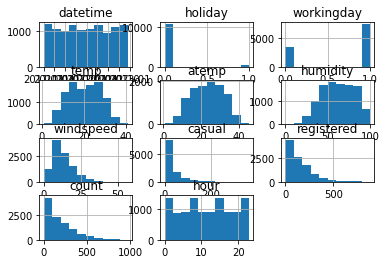

```python
# View histogram of all features again now with the hour feature
train.hist()
```

## Step 5: Rerun the model with the same settings as before, just with more features

```python
predictor_new_features = TabularPredictor(label="count",eval_metric="root_mean_squared_error", learner_kwargs={"ignored_columns": ["casual", "registered"]}).fit(train, time_limit=600, presets="best_quality")
```

```
No path specified. Models will be saved in: "AutogluonModels/ag-20221229_001738/"
Presets specified: ['best_quality']
Stack configuration (auto_stack=True): num_stack_levels=1, num_bag_folds=8, num_bag_sets=20
Beginning AutoGluon training ... Time limit = 600s
AutoGluon will save models to "AutogluonModels/ag-20221229_001738/"
AutoGluon Version:  0.6.1
Python Version:     3.7.10
Operating System:   Linux
Platform Machine:   x86_64
Platform Version:   #1 SMP Wed Oct 26 20:36:53 UTC 2022
Train Data Rows:    10886
Train Data Columns: 12
Label Column: count
Preprocessing data ...
AutoGluon infers your prediction problem is: 'regression' (because dtype of label-column == int and many unique label-values observed).
	Label info (max, min, mean, stddev): (977, 1, 191.57413, 181.14445)
	If 'regression' is not the correct problem_type, please manually specify the problem_type parameter during predictor init (You may specify problem_type as one of: ['binary', 'multiclass', 'regression'])
Using Feature Generators to preprocess the data ...
Dropping user-specified ignored columns: ['casual', 'registered']
Fitting AutoMLPipelineFeatureGenerator...
	Available Memory:                    2211.59 MB
	Train Data (Original)  Memory Usage: 0.72 MB (0.0% of available memory)
	Inferring data type of each feature based on column values. Set feature_metadata_in to manually specify special dtypes of the features.
	Stage 1 Generators:
		Fitting AsTypeFeatureGenerator...
			Note: Converting 2 features to boolean dtype as they only contain 2 unique values.
	Stage 2 Generators:
		Fitting FillNaFeatureGenerator...
	Stage 3 Generators:
		Fitting IdentityFeatureGenerator...
		Fitting CategoryFeatureGenerator...
			Fitting CategoryMemoryMinimizeFeatureGenerator...
		Fitting DatetimeFeatureGenerator...
	Stage 4 Generators:
		Fitting DropUniqueFeatureGenerator...
	Types of features in original data (raw dtype, special dtypes):
		('category', []) : 2 | ['season', 'weather']
		('datetime', []) : 1 | ['datetime']
		('float', [])    : 3 | ['temp', 'atemp', 'windspeed']
		('int', [])      : 4 | ['holiday', 'workingday', 'humidity', 'hour']
```

[output cut: 68 more lines]

```
	-31.6527	 = Validation score   (-root_mean_squared_error)
	28.72s	 = Training   runtime
	0.6s	 = Validation runtime
Fitting model: CatBoost_BAG_L2 ... Training model for up to 78.13s of the 78.11s of remaining time.
	Fitting 8 child models (S1F1 - S1F8) | Fitting with ParallelLocalFoldFittingStrategy
	-30.4832	 = Validation score   (-root_mean_squared_error)
	75.17s	 = Training   runtime
	0.1s	 = Validation runtime
Completed 1/20 k-fold bagging repeats ...
Fitting model: WeightedEnsemble_L3 ... Training model for up to 360.0s of the -1.01s of remaining time.
	-30.2074	 = Validation score   (-root_mean_squared_error)
	0.38s	 = Training   runtime
	0.0s	 = Validation runtime
AutoGluon training complete, total runtime = 601.58s ... Best model: "WeightedEnsemble_L3"
TabularPredictor saved. To load, use: predictor = TabularPredictor.load("AutogluonModels/ag-20221229_001738/")
```

```python
predictor_new_features.fit_summary()
```

```
*** Summary of fit() ***
Estimated performance of each model:
                     model   score_val  pred_time_val    fit_time  pred_time_val_marginal  fit_time_marginal  stack_level  can_infer  fit_order
0      WeightedEnsemble_L3  -30.207381      20.423516  559.298563                0.000740           0.379369            3       True         14
1          CatBoost_BAG_L2  -30.483223      18.499336  474.118758                0.102449          75.169806            2       True         13
2          LightGBM_BAG_L2  -30.581908      18.681674  423.847331                0.284788          24.898378            2       True         11
3        LightGBMXT_BAG_L2  -31.086115      19.437662  430.132512                1.040775          31.183559            2       True         10
4   RandomForestMSE_BAG_L2  -31.652673      18.994765  427.667451                0.597878          28.718498            2       True         12
5      WeightedEnsemble_L2  -32.165529      17.269933  351.233976                0.001278           0.674651            2       True          9
6          LightGBM_BAG_L1  -33.919639       3.139282   42.454666                3.139282          42.454666            1       True          4
7          CatBoost_BAG_L1  -33.966693       0.154865  204.689254                0.154865         204.689254            1       True          6
8        LightGBMXT_BAG_L1  -34.457274      13.308285   91.227556               13.308285          91.227556            1       True          3
9     ExtraTreesMSE_BAG_L1  -38.323016       0.550023    5.542880                0.550023           5.542880            1       True          7
10  RandomForestMSE_BAG_L1  -38.445932       0.562550   12.158430                0.562550          12.158430            1       True          5
11   KNeighborsDist_BAG_L1  -84.125061       0.103674    0.029419                0.103674           0.029419            1       True          2
12   KNeighborsUnif_BAG_L1 -101.546199       0.102775    0.028093                0.102775           0.028093            1       True          1
13  NeuralNetFastAI_BAG_L1 -103.514704       0.475432   42.818654                0.475432          42.818654            1       True          8
Number of models trained: 14
Types of models trained:
{'StackerEnsembleModel_NNFastAiTabular', 'StackerEnsembleModel_CatBoost', 'StackerEnsembleModel_XT', 'StackerEnsembleModel_KNN', 'StackerEnsembleModel_LGB', 'StackerEnsembleModel_RF', 'WeightedEnsembleModel'}
Bagging used: True  (with 8 folds)
Multi-layer stack-ensembling used: True  (with 3 levels)
Feature Metadata (Processed):
(raw dtype, special dtypes):
('category', [])             : 2 | ['season', 'weather']
('float', [])                : 3 | ['temp', 'atemp', 'windspeed']
('int', [])                  : 2 | ['humidity', 'hour']
('int', ['bool'])            : 2 | ['holiday', 'workingday']
('int', ['datetime_as_int']) : 5 | ['datetime', 'datetime.year', 'datetime.month', 'datetime.day', 'datetime.dayofweek']
Plot summary of models saved to file: AutogluonModels/ag-20221229_001738/SummaryOfModels.html
*** End of fit() summary ***
```

```
{'model_types': {'KNeighborsUnif_BAG_L1': 'StackerEnsembleModel_KNN',
  'KNeighborsDist_BAG_L1': 'StackerEnsembleModel_KNN',
  'LightGBMXT_BAG_L1': 'StackerEnsembleModel_LGB',
  'LightGBM_BAG_L1': 'StackerEnsembleModel_LGB',
  'RandomForestMSE_BAG_L1': 'StackerEnsembleModel_RF',
  'CatBoost_BAG_L1': 'StackerEnsembleModel_CatBoost',
  'ExtraTreesMSE_BAG_L1': 'StackerEnsembleModel_XT',
  'NeuralNetFastAI_BAG_L1': 'StackerEnsembleModel_NNFastAiTabular',
  'WeightedEnsemble_L2': 'WeightedEnsembleModel',
  'LightGBMXT_BAG_L2': 'StackerEnsembleModel_LGB',
  'LightGBM_BAG_L2': 'StackerEnsembleModel_LGB',
  'RandomForestMSE_BAG_L2': 'StackerEnsembleModel_RF',
  'CatBoost_BAG_L2': 'StackerEnsembleModel_CatBoost',
  'WeightedEnsemble_L3': 'WeightedEnsembleModel'},
 'model_performance': {'KNeighborsUnif_BAG_L1': -101.54619908446061,
  'KNeighborsDist_BAG_L1': -84.12506123181602,
  'LightGBMXT_BAG_L1': -34.457273921492806,
  'LightGBM_BAG_L1': -33.919639163586254,
  'RandomForestMSE_BAG_L1': -38.4459321324426,
  'CatBoost_BAG_L1': -33.966693376084685,
  'ExtraTreesMSE_BAG_L1': -38.3230160399388,
  'NeuralNetFastAI_BAG_L1': -103.51470398808046,
  'WeightedEnsemble_L2': -32.16552868507354,
  'LightGBMXT_BAG_L2': -31.08611450264992,
  'LightGBM_BAG_L2': -30.58190759565264,
  'RandomForestMSE_BAG_L2': -31.652672552736355,
  'CatBoost_BAG_L2': -30.48322262728734,
  'WeightedEnsemble_L3': -30.207380859444957},
 'model_best': 'WeightedEnsemble_L3',
 'model_paths': {'KNeighborsUnif_BAG_L1': 'AutogluonModels/ag-20221229_001738/models/KNeighborsUnif_BAG_L1/',
  'KNeighborsDist_BAG_L1': 'AutogluonModels/ag-20221229_001738/models/KNeighborsDist_BAG_L1/',
  'LightGBMXT_BAG_L1': 'AutogluonModels/ag-20221229_001738/models/LightGBMXT_BAG_L1/',
  'LightGBM_BAG_L1': 'AutogluonModels/ag-20221229_001738/models/LightGBM_BAG_L1/',
  'RandomForestMSE_BAG_L1': 'AutogluonModels/ag-20221229_001738/models/RandomForestMSE_BAG_L1/',
  'CatBoost_BAG_L1': 'AutogluonModels/ag-20221229_001738/models/CatBoost_BAG_L1/',
  'ExtraTreesMSE_BAG_L1': 'AutogluonModels/ag-20221229_001738/models/ExtraTreesMSE_BAG_L1/',
  'NeuralNetFastAI_BAG_L1': 'AutogluonModels/ag-20221229_001738/models/NeuralNetFastAI_BAG_L1/',
  'WeightedEnsemble_L2': 'AutogluonModels/ag-20221229_001738/models/WeightedEnsemble_L2/',
  'LightGBMXT_BAG_L2': 'AutogluonModels/ag-20221229_001738/models/LightGBMXT_BAG_L2/',
  'LightGBM_BAG_L2': 'AutogluonModels/ag-20221229_001738/models/LightGBM_BAG_L2/',
```

[output cut: 126 more lines]

```
     fit_order
 0          14
 1          13
 2          11
 3          10
 4          12
 5           9
 6           4
 7           6
 8           3
 9           7
 10          5
 11          2
 12          1
 13          8  }
```

```python
# Remember to set all negative values to zero
predictions_n_feature = predictor_new_features.predict(test.loc[:, test.columns != "count"])
print(predictions_n_feature[predictions_n_feature < 0].count())
predictions_n_feature[predictions_n_feature < 0] = 0
```

```
0
```

```python
# Same submitting predictions
submission_new_features = pd.read_csv("sampleSubmission.csv")
submission_new_features["count"] = predictions_n_feature
submission_new_features.to_csv("submission_new_features.csv", index=False)
```

```python
!kaggle competitions submit -c bike-sharing-demand -f submission_new_features.csv -m "new features"
```

```
Successfully submitted to Bike Sharing Demand
```

```python
!kaggle competitions submissions -c bike-sharing-demand | tail -n +1 | head -n 4
```

```
fileName                       date                 description                          status    publicScore  privateScore
-----------------------------  -------------------  -----------------------------------  --------  -----------  ------------
submission_new_features.csv    2022-12-29 00:28:27  new features                         complete  0.67743      0.67743
submission.csv                 2022-12-29 00:17:33  first raw submission                 complete  1.79209      1.79209
tail: write error: Broken pipe
```

## Step 6: Hyper parameter optimization

- There are many options for hyper parameter optimization.
- Options are to change the AutoGluon higher level parameters or the individual model hyperparameters.
- The hyperparameters of the models themselves that are in AutoGluon. Those need the `hyperparameter` and `hyperparameter_tune_kwargs` arguments.

```python
predictor_new_hpo = TabularPredictor(label="count", problem_type="regression", eval_metric="mean_absolute_error", learner_kwargs={"ignored_columns": ["casual", "registered"]}).fit(train_data=train, presets="high_quality",time_limit=700)
```

```
No path specified. Models will be saved in: "AutogluonModels/ag-20221229_002828/"
Presets specified: ['high_quality']
Stack configuration (auto_stack=True): num_stack_levels=1, num_bag_folds=8, num_bag_sets=20
Beginning AutoGluon training ... Time limit = 700s
AutoGluon will save models to "AutogluonModels/ag-20221229_002828/"
AutoGluon Version:  0.6.1
Python Version:     3.7.10
Operating System:   Linux
Platform Machine:   x86_64
Platform Version:   #1 SMP Wed Oct 26 20:36:53 UTC 2022
Train Data Rows:    10886
Train Data Columns: 12
Label Column: count
Preprocessing data ...
Using Feature Generators to preprocess the data ...
Dropping user-specified ignored columns: ['casual', 'registered']
Fitting AutoMLPipelineFeatureGenerator...
	Available Memory:                    2147.19 MB
	Train Data (Original)  Memory Usage: 0.72 MB (0.0% of available memory)
	Inferring data type of each feature based on column values. Set feature_metadata_in to manually specify special dtypes of the features.
	Stage 1 Generators:
		Fitting AsTypeFeatureGenerator...
			Note: Converting 2 features to boolean dtype as they only contain 2 unique values.
	Stage 2 Generators:
		Fitting FillNaFeatureGenerator...
	Stage 3 Generators:
		Fitting IdentityFeatureGenerator...
		Fitting CategoryFeatureGenerator...
			Fitting CategoryMemoryMinimizeFeatureGenerator...
		Fitting DatetimeFeatureGenerator...
	Stage 4 Generators:
		Fitting DropUniqueFeatureGenerator...
	Types of features in original data (raw dtype, special dtypes):
		('category', []) : 2 | ['season', 'weather']
		('datetime', []) : 1 | ['datetime']
		('float', [])    : 3 | ['temp', 'atemp', 'windspeed']
		('int', [])      : 4 | ['holiday', 'workingday', 'humidity', 'hour']
	Types of features in processed data (raw dtype, special dtypes):
		('category', [])             : 2 | ['season', 'weather']
		('float', [])                : 3 | ['temp', 'atemp', 'windspeed']
```

[output cut: 113 more lines]

```
Fitting 1 L2 models ...
Fitting model: LightGBM_BAG_L2_FULL ...
	0.82s	 = Training   runtime
Fitting model: RandomForestMSE_BAG_L2_FULL | Skipping fit via cloning parent ...
	29.82s	 = Training   runtime
	0.61s	 = Validation runtime
Fitting 1 L2 models ...
Fitting model: CatBoost_BAG_L2_FULL ...
	12.23s	 = Training   runtime
Fitting model: ExtraTreesMSE_BAG_L2_FULL | Skipping fit via cloning parent ...
	9.63s	 = Training   runtime
	0.62s	 = Validation runtime
Fitting model: WeightedEnsemble_L3_FULL | Skipping fit via cloning parent ...
	0.36s	 = Training   runtime
TabularPredictor saved. To load, use: predictor = TabularPredictor.load("AutogluonModels/ag-20221229_002828/")
```

```python
predictor_new_hpo.fit_summary()
```

```
*** Summary of fit() ***
Estimated performance of each model:
                          model  score_val  pred_time_val    fit_time  pred_time_val_marginal  fit_time_marginal  stack_level  can_infer  fit_order
0           WeightedEnsemble_L3 -18.462326      18.528152  662.976743                0.000768           0.360505            3      False         15
1               CatBoost_BAG_L2 -18.657958      15.963287  568.166593                0.127932         104.594310            2      False         13
2               LightGBM_BAG_L2 -18.825624      16.148824  489.659199                0.313469          26.086915            2      False         11
3             LightGBMXT_BAG_L2 -19.052643      16.857807  492.475527                1.022452          28.903243            2      False         10
4          ExtraTreesMSE_BAG_L2 -19.054657      16.452123  473.206907                0.616768           9.634623            2      False         14
5        RandomForestMSE_BAG_L2 -19.259782      16.446763  493.397148                0.611408          29.824864            2      False         12
6           WeightedEnsemble_L2 -19.676260      14.599001  403.059211                0.001007           0.548201            2      False          9
7               LightGBM_BAG_L1 -20.948628       2.995533   41.374675                2.995533          41.374675            1      False          4
8               CatBoost_BAG_L1 -21.256218       0.207985  269.840659                0.207985         269.840659            1      False          6
9             LightGBMXT_BAG_L1 -22.233997      10.835451   79.410817               10.835451          79.410817            1      False          3
10       RandomForestMSE_BAG_L1 -23.120025       0.559026   11.884859                0.559026          11.884859            1       True          5
11         ExtraTreesMSE_BAG_L1 -23.963989       0.555931    5.559805                0.555931           5.559805            1       True          7
12        KNeighborsDist_BAG_L1 -52.047413       0.103803    0.027512                0.103803           0.027512            1       True          2
13       NeuralNetFastAI_BAG_L1 -54.323623       0.474803   55.443830                0.474803          55.443830            1      False          8
14        KNeighborsUnif_BAG_L1 -64.737939       0.102824    0.030127                0.102824           0.030127            1       True          1
15   KNeighborsUnif_BAG_L1_FULL        NaN       0.102824    0.030127                0.102824           0.030127            1       True         16
16   KNeighborsDist_BAG_L1_FULL        NaN       0.103803    0.027512                0.103803           0.027512            1       True         17
17    ExtraTreesMSE_BAG_L1_FULL        NaN       0.555931    5.559805                0.555931           5.559805            1       True         22
18  RandomForestMSE_BAG_L1_FULL        NaN       0.559026   11.884859                0.559026          11.884859            1       True         20
19     WeightedEnsemble_L3_FULL        NaN            NaN  116.103223                     NaN           0.360505            3       True         30
20     WeightedEnsemble_L2_FULL        NaN            NaN   52.530761                     NaN           0.548201            2       True         24
21  RandomForestMSE_BAG_L2_FULL        NaN            NaN   91.774759                0.611408          29.824864            2       True         27
22  NeuralNetFastAI_BAG_L1_FULL        NaN            NaN    4.349891                     NaN           4.349891            1       True         23
23         LightGBM_BAG_L2_FULL        NaN            NaN   62.774459                     NaN           0.824564            2       True         26
24         LightGBM_BAG_L1_FULL        NaN            NaN    2.453357                     NaN           2.453357            1       True         19
25       LightGBMXT_BAG_L2_FULL        NaN            NaN   63.232343                     NaN           1.282448            2       True         25
26       LightGBMXT_BAG_L1_FULL        NaN            NaN    6.316487                     NaN           6.316487            1       True         18
27    ExtraTreesMSE_BAG_L2_FULL        NaN            NaN   71.584518                0.616768           9.634623            2       True         29
28         CatBoost_BAG_L2_FULL        NaN            NaN   74.176219                     NaN          12.226324            2       True         28
29         CatBoost_BAG_L1_FULL        NaN            NaN   31.327857                     NaN          31.327857            1       True         21
Number of models trained: 30
Types of models trained:
{'StackerEnsembleModel_NNFastAiTabular', 'StackerEnsembleModel_CatBoost', 'StackerEnsembleModel_XT', 'StackerEnsembleModel_KNN', 'StackerEnsembleModel_LGB', 'StackerEnsembleModel_RF', 'WeightedEnsembleModel'}
Bagging used: True  (with 8 folds)
Multi-layer stack-ensembling used: True  (with 3 levels)
Feature Metadata (Processed):
(raw dtype, special dtypes):
('category', [])             : 2 | ['season', 'weather']
('float', [])                : 3 | ['temp', 'atemp', 'windspeed']
('int', [])                  : 2 | ['humidity', 'hour']
('int', ['bool'])            : 2 | ['holiday', 'workingday']
('int', ['datetime_as_int']) : 5 | ['datetime', 'datetime.year', 'datetime.month', 'datetime.day', 'datetime.dayofweek']
Plot summary of models saved to file: AutogluonModels/ag-20221229_002828/SummaryOfModels.html
*** End of fit() summary ***
```

```
{'model_types': {'KNeighborsUnif_BAG_L1': 'StackerEnsembleModel_KNN',
  'KNeighborsDist_BAG_L1': 'StackerEnsembleModel_KNN',
  'LightGBMXT_BAG_L1': 'StackerEnsembleModel_LGB',
  'LightGBM_BAG_L1': 'StackerEnsembleModel_LGB',
  'RandomForestMSE_BAG_L1': 'StackerEnsembleModel_RF',
  'CatBoost_BAG_L1': 'StackerEnsembleModel_CatBoost',
  'ExtraTreesMSE_BAG_L1': 'StackerEnsembleModel_XT',
  'NeuralNetFastAI_BAG_L1': 'StackerEnsembleModel_NNFastAiTabular',
  'WeightedEnsemble_L2': 'WeightedEnsembleModel',
  'LightGBMXT_BAG_L2': 'StackerEnsembleModel_LGB',
  'LightGBM_BAG_L2': 'StackerEnsembleModel_LGB',
  'RandomForestMSE_BAG_L2': 'StackerEnsembleModel_RF',
  'CatBoost_BAG_L2': 'StackerEnsembleModel_CatBoost',
  'ExtraTreesMSE_BAG_L2': 'StackerEnsembleModel_XT',
  'WeightedEnsemble_L3': 'WeightedEnsembleModel',
  'KNeighborsUnif_BAG_L1_FULL': 'StackerEnsembleModel_KNN',
  'KNeighborsDist_BAG_L1_FULL': 'StackerEnsembleModel_KNN',
  'LightGBMXT_BAG_L1_FULL': 'StackerEnsembleModel_LGB',
  'LightGBM_BAG_L1_FULL': 'StackerEnsembleModel_LGB',
  'RandomForestMSE_BAG_L1_FULL': 'StackerEnsembleModel_RF',
  'CatBoost_BAG_L1_FULL': 'StackerEnsembleModel_CatBoost',
  'ExtraTreesMSE_BAG_L1_FULL': 'StackerEnsembleModel_XT',
  'NeuralNetFastAI_BAG_L1_FULL': 'StackerEnsembleModel_NNFastAiTabular',
  'WeightedEnsemble_L2_FULL': 'WeightedEnsembleModel',
  'LightGBMXT_BAG_L2_FULL': 'StackerEnsembleModel_LGB',
  'LightGBM_BAG_L2_FULL': 'StackerEnsembleModel_LGB',
  'RandomForestMSE_BAG_L2_FULL': 'StackerEnsembleModel_RF',
  'CatBoost_BAG_L2_FULL': 'StackerEnsembleModel_CatBoost',
  'ExtraTreesMSE_BAG_L2_FULL': 'StackerEnsembleModel_XT',
  'WeightedEnsemble_L3_FULL': 'WeightedEnsembleModel'},
 'model_performance': {'KNeighborsUnif_BAG_L1': -64.73793861720571,
  'KNeighborsDist_BAG_L1': -52.047412500976314,
  'LightGBMXT_BAG_L1': -22.233996671414452,
  'LightGBM_BAG_L1': -20.94862834415336,
  'RandomForestMSE_BAG_L1': -23.12002499222252,
  'CatBoost_BAG_L1': -21.25621803316243,
  'ExtraTreesMSE_BAG_L1': -23.96398855855573,
  'NeuralNetFastAI_BAG_L1': -54.3236231738657,
  'WeightedEnsemble_L2': -19.676259915492082,
  'LightGBMXT_BAG_L2': -19.052643072183805,
```

[output cut: 325 more lines]

```
 15         16
 16         17
 17         22
 18         20
 19         30
 20         24
 21         27
 22         23
 23         26
 24         19
 25         25
 26         18
 27         29
 28         28
 29         21  }
```

```python
# Remember to set all negative values to zero
predictions_hpo = predictor_new_hpo.predict(test)
print(predictions_hpo[predictions_hpo < 0].count())
predictions_hpo[predictions_hpo < 0] = 0
```

```
0
```

```python
submission_new_hpo = pd.read_csv("sampleSubmission.csv")
```

```python
# Same submitting predictions
submission_new_hpo["count"] = predictions_hpo
submission_new_hpo.to_csv("submission_new_hpo.csv", index=False)
```

```python
!kaggle competitions submit -c bike-sharing-demand -f submission_new_hpo.csv -m "new features with hyperparameters"
```

```
Successfully submitted to Bike Sharing Demand
```

```python
!kaggle competitions submissions -c bike-sharing-demand | tail -n +1 | head -n 5
```

```
fileName                       date                 description                          status    publicScore  privateScore
-----------------------------  -------------------  -----------------------------------  --------  -----------  ------------
submission_new_hpo.csv         2022-12-29 00:41:44  new features with hyperparameters    complete  0.69137      0.69137
submission_new_features.csv    2022-12-29 00:28:27  new features                         complete  0.67743      0.67743
submission.csv                 2022-12-29 00:17:33  first raw submission                 complete  1.79209      1.79209
tail: write error: Broken pipe
```

```python
## Stand Out Suggestions
```

```python
# Adding new features

train["day"] = train["datetime"].dt.day
test["day"] = test["datetime"].dt.day
train["month"] = train["datetime"].dt.month
test["month"] = test["datetime"].dt.month
train["year"] = train["datetime"].dt.year
test["year"] = test["datetime"].dt.year
```

```python
train.info()
```

```
<class 'pandas.core.frame.DataFrame'>
RangeIndex: 10886 entries, 0 to 10885
Data columns (total 16 columns):
 #   Column      Non-Null Count  Dtype
---  ------      --------------  -----
 0   datetime    10886 non-null  datetime64[ns]
 1   season      10886 non-null  category
 2   holiday     10886 non-null  int64
 3   workingday  10886 non-null  int64
 4   weather     10886 non-null  category
 5   temp        10886 non-null  float64
 6   atemp       10886 non-null  float64
 7   humidity    10886 non-null  int64
 8   windspeed   10886 non-null  float64
 9   casual      10886 non-null  int64
 10  registered  10886 non-null  int64
 11  count       10886 non-null  int64
 12  hour        10886 non-null  int64
 13  day         10886 non-null  int64
 14  month       10886 non-null  int64
 15  year        10886 non-null  int64
dtypes: category(2), datetime64[ns](1), float64(3), int64(10)
memory usage: 1.2 MB
```

```python
test.info()
```

```
<class 'pandas.core.frame.DataFrame'>
RangeIndex: 6493 entries, 0 to 6492
Data columns (total 13 columns):
 #   Column      Non-Null Count  Dtype
---  ------      --------------  -----
 0   datetime    6493 non-null   datetime64[ns]
 1   season      6493 non-null   category
 2   holiday     6493 non-null   int64
 3   workingday  6493 non-null   int64
 4   weather     6493 non-null   category
 5   temp        6493 non-null   float64
 6   atemp       6493 non-null   float64
 7   humidity    6493 non-null   int64
 8   windspeed   6493 non-null   float64
 9   hour        6493 non-null   int64
 10  day         6493 non-null   int64
 11  month       6493 non-null   int64
 12  year        6493 non-null   int64
dtypes: category(2), datetime64[ns](1), float64(3), int64(7)
memory usage: 571.2 KB
```

### I am going to ignore the datetime column because it was splitted in four parts :year, month, day and hour

```python
## training with new features
predictor_new_features_2 = TabularPredictor(label="count", problem_type="regression", eval_metric="mean_absolute_error", learner_kwargs={"ignored_columns": ["casual", "registered", "datetime"]}).fit(train_data=train, presets="high_quality",time_limit=700)
```

```
No path specified. Models will be saved in: "AutogluonModels/ag-20221229_004146/"
Presets specified: ['high_quality']
Stack configuration (auto_stack=True): num_stack_levels=1, num_bag_folds=8, num_bag_sets=20
Beginning AutoGluon training ... Time limit = 700s
AutoGluon will save models to "AutogluonModels/ag-20221229_004146/"
AutoGluon Version:  0.6.1
Python Version:     3.7.10
Operating System:   Linux
Platform Machine:   x86_64
Platform Version:   #1 SMP Wed Oct 26 20:36:53 UTC 2022
Train Data Rows:    10886
Train Data Columns: 15
Label Column: count
Preprocessing data ...
Using Feature Generators to preprocess the data ...
Dropping user-specified ignored columns: ['casual', 'registered', 'datetime']
Fitting AutoMLPipelineFeatureGenerator...
	Available Memory:                    2097.75 MB
	Train Data (Original)  Memory Usage: 0.89 MB (0.0% of available memory)
	Inferring data type of each feature based on column values. Set feature_metadata_in to manually specify special dtypes of the features.
	Stage 1 Generators:
		Fitting AsTypeFeatureGenerator...
			Note: Converting 3 features to boolean dtype as they only contain 2 unique values.
	Stage 2 Generators:
		Fitting FillNaFeatureGenerator...
	Stage 3 Generators:
		Fitting IdentityFeatureGenerator...
		Fitting CategoryFeatureGenerator...
			Fitting CategoryMemoryMinimizeFeatureGenerator...
	Stage 4 Generators:
		Fitting DropUniqueFeatureGenerator...
	Types of features in original data (raw dtype, special dtypes):
		('category', []) : 2 | ['season', 'weather']
		('float', [])    : 3 | ['temp', 'atemp', 'windspeed']
		('int', [])      : 7 | ['holiday', 'workingday', 'humidity', 'hour', 'day', ...]
	Types of features in processed data (raw dtype, special dtypes):
		('category', [])  : 2 | ['season', 'weather']
		('float', [])     : 3 | ['temp', 'atemp', 'windspeed']
		('int', [])       : 4 | ['humidity', 'hour', 'day', 'month']
		('int', ['bool']) : 3 | ['holiday', 'workingday', 'year']
```

[output cut: 119 more lines]

```
	27.1s	 = Training   runtime
	0.61s	 = Validation runtime
Fitting 1 L2 models ...
Fitting model: CatBoost_BAG_L2_FULL ...
	5.02s	 = Training   runtime
Fitting model: ExtraTreesMSE_BAG_L2_FULL | Skipping fit via cloning parent ...
	7.97s	 = Training   runtime
	0.59s	 = Validation runtime
Fitting 1 L2 models ...
Fitting model: NeuralNetFastAI_BAG_L2_FULL ...
	Stopping at the best epoch learned earlier - 9.
	5.73s	 = Training   runtime
Fitting model: WeightedEnsemble_L3_FULL | Skipping fit via cloning parent ...
	0.3s	 = Training   runtime
TabularPredictor saved. To load, use: predictor = TabularPredictor.load("AutogluonModels/ag-20221229_004146/")
```

```python
predictor_new_features_2.fit_summary()
```

```
*** Summary of fit() ***
Estimated performance of each model:
                          model  score_val  pred_time_val    fit_time  pred_time_val_marginal  fit_time_marginal  stack_level  can_infer  fit_order
0           WeightedEnsemble_L3 -22.427536      23.448024  648.023036                0.000802           0.297921            3      False         16
1          ExtraTreesMSE_BAG_L2 -22.655111      21.981213  469.986285                0.588494           7.968478            2      False         14
2               CatBoost_BAG_L2 -22.672439      21.483951  528.987050                0.091232          66.969244            2      False         13
3           WeightedEnsemble_L2 -22.756197      19.842662  403.080856                0.001004           0.431428            2      False          9
4               LightGBM_BAG_L2 -22.846490      21.561186  484.849070                0.168468          22.831264            2      False         11
5        RandomForestMSE_BAG_L2 -22.983805      21.998434  489.121419                0.605716          27.103613            2      False         12
6             LightGBMXT_BAG_L2 -23.076817      21.734242  485.823068                0.341524          23.805262            2      False         10
7        NeuralNetFastAI_BAG_L2 -23.396852      21.993312  522.852515                0.600593          60.834709            2      False         15
8               LightGBM_BAG_L1 -24.032382       3.155471   39.647420                3.155471          39.647420            1      False          4
9             LightGBMXT_BAG_L1 -24.178405      15.947893   82.841433               15.947893          82.841433            1      False          3
10              CatBoost_BAG_L1 -24.486269       0.176362  270.293247                0.176362         270.293247            1      False          6
11       RandomForestMSE_BAG_L1 -26.368508       0.561932    9.867328                0.561932           9.867328            1       True          5
12         ExtraTreesMSE_BAG_L1 -26.726988       0.563185    5.053502                0.563185           5.053502            1       True          7
13       NeuralNetFastAI_BAG_L1 -50.518952       0.576516   54.262989                0.576516          54.262989            1      False          8
14        KNeighborsDist_BAG_L1 -80.440710       0.208323    0.025154                0.208323           0.025154            1       True          2
15        KNeighborsUnif_BAG_L1 -84.498641       0.203035    0.026734                0.203035           0.026734            1       True          1
16   KNeighborsUnif_BAG_L1_FULL        NaN       0.203035    0.026734                0.203035           0.026734            1       True         17
17   KNeighborsDist_BAG_L1_FULL        NaN       0.208323    0.025154                0.208323           0.025154            1       True         18
18  RandomForestMSE_BAG_L1_FULL        NaN       0.561932    9.867328                0.561932           9.867328            1       True         21
19    ExtraTreesMSE_BAG_L1_FULL        NaN       0.563185    5.053502                0.563185           5.053502            1       True         23
20     WeightedEnsemble_L3_FULL        NaN            NaN  105.270717                     NaN           0.297921            3       True         32
21     WeightedEnsemble_L2_FULL        NaN            NaN   50.151305                     NaN           0.431428            2       True         25
22  RandomForestMSE_BAG_L2_FULL        NaN            NaN   85.777926                0.605716          27.103613            2       True         28
23  NeuralNetFastAI_BAG_L2_FULL        NaN            NaN   64.404400                     NaN           5.730087            2       True         31
24  NeuralNetFastAI_BAG_L1_FULL        NaN            NaN    3.849046                     NaN           3.849046            1       True         24
25         LightGBM_BAG_L2_FULL        NaN            NaN   59.147726                     NaN           0.473413            2       True         27
26         LightGBM_BAG_L1_FULL        NaN            NaN    2.603871                     NaN           2.603871            1       True         20
27       LightGBMXT_BAG_L2_FULL        NaN            NaN   59.302340                     NaN           0.628026            2       True         26
28       LightGBMXT_BAG_L1_FULL        NaN            NaN    7.149191                     NaN           7.149191            1       True         19
29    ExtraTreesMSE_BAG_L2_FULL        NaN            NaN   66.642792                0.588494           7.968478            2       True         30
30         CatBoost_BAG_L2_FULL        NaN            NaN   63.697204                     NaN           5.022891            2       True         29
31         CatBoost_BAG_L1_FULL        NaN            NaN   30.099487                     NaN          30.099487            1       True         22
Number of models trained: 32
Types of models trained:
{'StackerEnsembleModel_NNFastAiTabular', 'StackerEnsembleModel_CatBoost', 'StackerEnsembleModel_XT', 'StackerEnsembleModel_KNN', 'StackerEnsembleModel_LGB', 'StackerEnsembleModel_RF', 'WeightedEnsembleModel'}
Bagging used: True  (with 8 folds)
Multi-layer stack-ensembling used: True  (with 3 levels)
Feature Metadata (Processed):
(raw dtype, special dtypes):
('category', [])  : 2 | ['season', 'weather']
('float', [])     : 3 | ['temp', 'atemp', 'windspeed']
('int', [])       : 4 | ['humidity', 'hour', 'day', 'month']
('int', ['bool']) : 3 | ['holiday', 'workingday', 'year']
Plot summary of models saved to file: AutogluonModels/ag-20221229_004146/SummaryOfModels.html
*** End of fit() summary ***
```

```
{'model_types': {'KNeighborsUnif_BAG_L1': 'StackerEnsembleModel_KNN',
  'KNeighborsDist_BAG_L1': 'StackerEnsembleModel_KNN',
  'LightGBMXT_BAG_L1': 'StackerEnsembleModel_LGB',
  'LightGBM_BAG_L1': 'StackerEnsembleModel_LGB',
  'RandomForestMSE_BAG_L1': 'StackerEnsembleModel_RF',
  'CatBoost_BAG_L1': 'StackerEnsembleModel_CatBoost',
  'ExtraTreesMSE_BAG_L1': 'StackerEnsembleModel_XT',
  'NeuralNetFastAI_BAG_L1': 'StackerEnsembleModel_NNFastAiTabular',
  'WeightedEnsemble_L2': 'WeightedEnsembleModel',
  'LightGBMXT_BAG_L2': 'StackerEnsembleModel_LGB',
  'LightGBM_BAG_L2': 'StackerEnsembleModel_LGB',
  'RandomForestMSE_BAG_L2': 'StackerEnsembleModel_RF',
  'CatBoost_BAG_L2': 'StackerEnsembleModel_CatBoost',
  'ExtraTreesMSE_BAG_L2': 'StackerEnsembleModel_XT',
  'NeuralNetFastAI_BAG_L2': 'StackerEnsembleModel_NNFastAiTabular',
  'WeightedEnsemble_L3': 'WeightedEnsembleModel',
  'KNeighborsUnif_BAG_L1_FULL': 'StackerEnsembleModel_KNN',
  'KNeighborsDist_BAG_L1_FULL': 'StackerEnsembleModel_KNN',
  'LightGBMXT_BAG_L1_FULL': 'StackerEnsembleModel_LGB',
  'LightGBM_BAG_L1_FULL': 'StackerEnsembleModel_LGB',
  'RandomForestMSE_BAG_L1_FULL': 'StackerEnsembleModel_RF',
  'CatBoost_BAG_L1_FULL': 'StackerEnsembleModel_CatBoost',
  'ExtraTreesMSE_BAG_L1_FULL': 'StackerEnsembleModel_XT',
  'NeuralNetFastAI_BAG_L1_FULL': 'StackerEnsembleModel_NNFastAiTabular',
  'WeightedEnsemble_L2_FULL': 'WeightedEnsembleModel',
  'LightGBMXT_BAG_L2_FULL': 'StackerEnsembleModel_LGB',
  'LightGBM_BAG_L2_FULL': 'StackerEnsembleModel_LGB',
  'RandomForestMSE_BAG_L2_FULL': 'StackerEnsembleModel_RF',
  'CatBoost_BAG_L2_FULL': 'StackerEnsembleModel_CatBoost',
  'ExtraTreesMSE_BAG_L2_FULL': 'StackerEnsembleModel_XT',
  'NeuralNetFastAI_BAG_L2_FULL': 'StackerEnsembleModel_NNFastAiTabular',
  'WeightedEnsemble_L3_FULL': 'WeightedEnsembleModel'},
 'model_performance': {'KNeighborsUnif_BAG_L1': -84.49864051285286,
  'KNeighborsDist_BAG_L1': -80.44070961095164,
  'LightGBMXT_BAG_L1': -24.17840464609393,
  'LightGBM_BAG_L1': -24.03238185589485,
  'RandomForestMSE_BAG_L1': -26.368508378843515,
  'CatBoost_BAG_L1': -24.486268659115336,
  'ExtraTreesMSE_BAG_L1': -26.726988475769073,
  'NeuralNetFastAI_BAG_L1': -50.51895176022872,
```

[output cut: 349 more lines]

```
 17         18
 18         21
 19         23
 20         32
 21         25
 22         28
 23         31
 24         24
 25         27
 26         20
 27         26
 28         19
 29         30
 30         29
 31         22  }
```

```python
# Remember to set all negative values to zero
predictions_n_features_2 = predictor_new_features_2.predict(test.loc[:, test.columns != "datetime"])
print(predictions_n_features_2[predictions_n_features_2 < 0].count())
predictions_n_features_2[predictions_n_features_2 < 0] = 0
submission_new_features_2 = pd.read_csv("sampleSubmission.csv")
```

```
0
```

```python
submission_new_features_2["count"] = predictions_n_features_2
submission_new_features_2.to_csv("submission_new_features_2.csv", index=False)

!kaggle competitions submit -c bike-sharing-demand -f submission_new_features_2.csv -m "new features -> day, month and year"
```

```
Successfully submitted to Bike Sharing Demand
```

```python
!kaggle competitions submissions -c bike-sharing-demand | tail -n +1 | head -n 6
```

```
fileName                       date                 description                          status    publicScore  privateScore
-----------------------------  -------------------  -----------------------------------  --------  -----------  ------------
submission_new_features_2.csv  2022-12-29 00:55:17  new features -> day, month and year  complete  0.45839      0.45839
submission_new_hpo.csv         2022-12-29 00:41:44  new features with hyperparameters    complete  0.69137      0.69137
submission_new_features.csv    2022-12-29 00:28:27  new features                         complete  0.67743      0.67743
submission.csv                 2022-12-29 00:17:33  first raw submission                 complete  1.79209      1.79209
tail: write error: Broken pipe
```

## Step 7: Write a Report

### Refer to the markdown file for the full report

### Creating plots and table for report

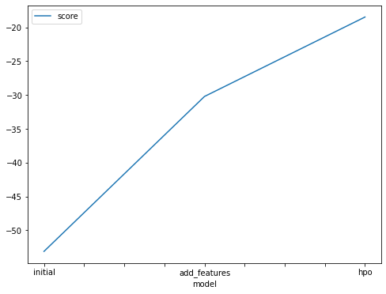

```python
# Taking the top model score from each training run and creating a line plot to show improvement
# You can create these in the notebook and save them to PNG or use some other tool (e.g. google sheets, excel)
fig = pd.DataFrame(
    {
        "model": ["initial", "add_features", "hpo"],
        "score": [-53.117461 ,-30.207381 ,-18.462326]
    }
).plot(x="model", y="score", figsize=(8, 6)).get_figure()
fig.savefig('img/model_train_score.png')
```

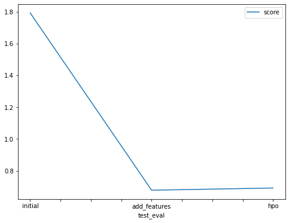

```python
# Take the 3 kaggle scores and creating a line plot to show improvement
fig = pd.DataFrame(
    {
        "test_eval": ["initial", "add_features", "hpo"],
        "score":[ 1.79209, 0.67743, 0.69137]
    }
).plot(x="test_eval", y="score", figsize=(8, 6)).get_figure()
fig.savefig('img/model_test_score.png')
```

### Hyperparameter table

```python
# The 3 hyperparameters we tuned with the kaggle score as the result
df = pd.DataFrame({
    "model": ["initial", "add_features", "hpo"],
    "time_limit": [600, 600, 700],
    "eval_metric": ["root_mean_square_error", "root_mean_square_error", "mean_absolute_error"],
    "presets": ["best_quality", "best_quality", "high_quality"],
    "score":[ 1.79209, 0.67743, 0.69137]
})
df.to_csv("ext/summary.csv")
df.head()
```

|  | model | time_limit | eval_metric | presets | score |
| --- | --- | --- | --- | --- | --- |
| 0 | initial | 600 | root_mean_square_error | best_quality | 1.79209 |
| 1 | add_features | 600 | root_mean_square_error | best_quality | 0.67743 |
| 2 | hpo | 700 | mean_absolute_error | high_quality | 0.69137 |

### This section is extra. Stand Out Suggestions.

```python
### Correlation Matrix.
corr = train.corr()
corr.style.background_gradient(cmap='coolwarm')
```

|  | holiday | workingday | temp | atemp | humidity | windspeed | casual | registered | count | hour | day | month | year |
| --- | --- | --- | --- | --- | --- | --- | --- | --- | --- | --- | --- | --- | --- |
| holiday | 1.000000 | -0.250491 | 0.000295 | -0.005215 | 0.001929 | 0.008409 | 0.043799 | -0.020956 | -0.005393 | -0.000354 | -0.015877 | 0.001731 | 0.012021 |
| workingday | -0.250491 | 1.000000 | 0.029966 | 0.024660 | -0.010880 | 0.013373 | -0.319111 | 0.119460 | 0.011594 | 0.002780 | 0.009829 | -0.003394 | -0.002482 |
| temp | 0.000295 | 0.029966 | 1.000000 | 0.984948 | -0.064949 | -0.017852 | 0.467097 | 0.318571 | 0.394454 | 0.145430 | 0.015551 | 0.257589 | 0.061226 |
| atemp | -0.005215 | 0.024660 | 0.984948 | 1.000000 | -0.043536 | -0.057473 | 0.462067 | 0.314635 | 0.389784 | 0.140343 | 0.011866 | 0.264173 | 0.058540 |
| humidity | 0.001929 | -0.010880 | -0.064949 | -0.043536 | 1.000000 | -0.318607 | -0.348187 | -0.265458 | -0.317371 | -0.278011 | -0.011335 | 0.204537 | -0.078606 |
| windspeed | 0.008409 | 0.013373 | -0.017852 | -0.057473 | -0.318607 | 1.000000 | 0.092276 | 0.091052 | 0.101369 | 0.146631 | 0.036157 | -0.150192 | -0.015221 |
| casual | 0.043799 | -0.319111 | 0.467097 | 0.462067 | -0.348187 | 0.092276 | 1.000000 | 0.497250 | 0.690414 | 0.302045 | 0.014109 | 0.092722 | 0.145241 |
| registered | -0.020956 | 0.119460 | 0.318571 | 0.314635 | -0.265458 | 0.091052 | 0.497250 | 1.000000 | 0.970948 | 0.380540 | 0.019111 | 0.169451 | 0.264265 |
| count | -0.005393 | 0.011594 | 0.394454 | 0.389784 | -0.317371 | 0.101369 | 0.690414 | 0.970948 | 1.000000 | 0.400601 | 0.019826 | 0.166862 | 0.260403 |
| hour | -0.000354 | 0.002780 | 0.145430 | 0.140343 | -0.278011 | 0.146631 | 0.302045 | 0.380540 | 0.400601 | 1.000000 | 0.001132 | -0.006818 | -0.004234 |
| day | -0.015877 | 0.009829 | 0.015551 | 0.011866 | -0.011335 | 0.036157 | 0.014109 | 0.019111 | 0.019826 | 0.001132 | 1.000000 | 0.001974 | 0.001800 |
| month | 0.001731 | -0.003394 | 0.257589 | 0.264173 | 0.204537 | -0.150192 | 0.092722 | 0.169451 | 0.166862 | -0.006818 | 0.001974 | 1.000000 | -0.004932 |
| year | 0.012021 | -0.002482 | 0.061226 | 0.058540 | -0.078606 | -0.015221 | 0.145241 | 0.264265 | 0.260403 | -0.004234 | 0.001800 | -0.004932 | 1.000000 |

How we can see, the variables temp and atemp are very correlated with a score of 0.984948.

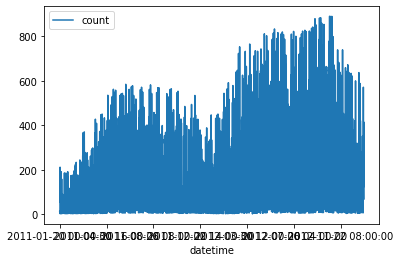

```python
### Time series on  the best model
submission_new_features_2.plot( 'datetime' , 'count')
```

In the figure above, we can notice that model predict an increase in bike sharing demand for the last months of the year.

### With the last model "predictor_new_feautes_2"

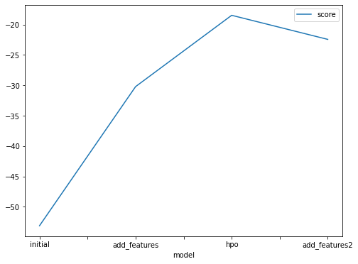

```python
fig = pd.DataFrame(
    {
        "model": ["initial", "add_features", "hpo",  "add_features2"],
        "score":  [-53.117461 ,-30.207381 ,-18.462326, -22.427536]
    }
).plot(x="model", y="score", figsize=(8, 6)).get_figure()
fig.savefig('img/model_train_extended_score.png')
```

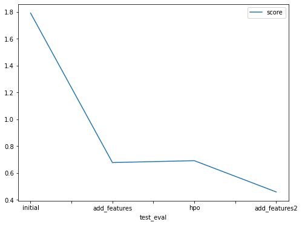

```python
fig = pd.DataFrame(
    {
        "test_eval": ["initial", "add_features", "hpo", "add_features2"],
        "score": [ 1.79209, 0.67743, 0.69137, 0.45839]
    }
).plot(x="test_eval", y="score", figsize=(8, 6)).get_figure()
fig.savefig('img/model_test_extended_score.png')
```

```python
df = pd.DataFrame({
    "model": ["initial", "add_features", "hpo", "add_features_2"],
    "time_limit": [600, 600, 700, 700],
    "eval_metric": ["root_mean_square_error", "root_mean_square_error", "mean_absolute_error", "mean_absolute_error"],
    "presets": ["best_quality", "best_quality", "high_quality", "high_quality"],
    "score":[ 1.79209, 0.67743, 0.69137, 0.45839]
})
df.to_csv("ext/summary_extended.csv")
df.head()
```

|  | model | time_limit | eval_metric | presets | score |
| --- | --- | --- | --- | --- | --- |
| 0 | initial | 600 | root_mean_square_error | best_quality | 1.79209 |
| 1 | add_features | 600 | root_mean_square_error | best_quality | 0.67743 |
| 2 | hpo | 700 | mean_absolute_error | high_quality | 0.69137 |
| 3 | add_features_2 | 700 | mean_absolute_error | high_quality | 0.45839 |